# Practical machine learning project

Vimala

30/03/2020

## 1. Executive summary:

The objective of this exercise is to predict the manner a given weight lifter performed the execrcise. The manner by which the exercise is done is bucketed under 5 categories A, B, C, D and E. This is represented by “classe” variable. The given dataset had numerous predictor variables. The variables were different quality measures indicating the way the exercise was done. After data cleansing, a list 52 variables were used for prediction. For this scope of exercise, two machine learning methods: 1. Classification tree and 2. Random forest were explored. Between the two models, random forest model provided about overall 99% accuracy.

## 2. Load input data and load required libraries

```r
library(caret)
library(rattle)
library(kernlab)
DataInput <- read.csv("C:/Users/Vimala.Chakravarthy/Desktop/Vimala/Training/R/Machine learning/pml-training.csv", header =TRUE)
#head(DataInput)
```

## 3. Data quality assessment

# remove first seven columns that carry no value

It can be seen from the dataset that first seven columns merely provide identification information and would not help much in our prediction

```r
DataInputInd <- DataInput[, -c(1:7)]
#head(DataInputInd)
dim(DataInputInd)
```

```
## [1] 19622   153
```

# remove missing values or columns having NA for 20% of time

One of the important step in building models is to ensure that the data used for prediction is of good quality. Often, the dataset with missing values produce biased estimates. Among the most popular ways to address missing values problem, i decided to remove the columns with more than 20% missing values. Imputation is not considered because creating proxy for more than 20% of values may again lead to bias. As seen from the results, we still have enough number predictors (52) after removing the columns with missing values. In order to make sure we are not removing meaningful predictors, the accuracy and other performance metrics could be analysed.

```r
cols_with_missing_values = which(colSums(is.na(DataInputInd) | DataInputInd == "") > 19622*0.2)
cols_with_missing_values
```

```
##       kurtosis_roll_belt      kurtosis_picth_belt        kurtosis_yaw_belt
##                        5                        6                        7
##       skewness_roll_belt     skewness_roll_belt.1        skewness_yaw_belt
##                        8                        9                       10
##            max_roll_belt           max_picth_belt             max_yaw_belt
##                       11                       12                       13
##            min_roll_belt           min_pitch_belt             min_yaw_belt
##                       14                       15                       16
##      amplitude_roll_belt     amplitude_pitch_belt       amplitude_yaw_belt
##                       17                       18                       19
##     var_total_accel_belt            avg_roll_belt         stddev_roll_belt
##                       20                       21                       22
##            var_roll_belt           avg_pitch_belt        stddev_pitch_belt
##                       23                       24                       25
##           var_pitch_belt             avg_yaw_belt          stddev_yaw_belt
##                       26                       27                       28
##             var_yaw_belt            var_accel_arm             avg_roll_arm
##                       29                       43                       44
##          stddev_roll_arm             var_roll_arm            avg_pitch_arm
##                       45                       46                       47
##         stddev_pitch_arm            var_pitch_arm              avg_yaw_arm
##                       48                       49                       50
##           stddev_yaw_arm              var_yaw_arm        kurtosis_roll_arm
##                       51                       52                       62
##       kurtosis_picth_arm         kurtosis_yaw_arm        skewness_roll_arm
##                       63                       64                       65
##       skewness_pitch_arm         skewness_yaw_arm             max_roll_arm
##                       66                       67                       68
##            max_picth_arm              max_yaw_arm             min_roll_arm
##                       69                       70                       71
##            min_pitch_arm              min_yaw_arm       amplitude_roll_arm
##                       72                       73                       74
##      amplitude_pitch_arm        amplitude_yaw_arm   kurtosis_roll_dumbbell
##                       75                       76                       80
##  kurtosis_picth_dumbbell    kurtosis_yaw_dumbbell   skewness_roll_dumbbell
##                       81                       82                       83
##  skewness_pitch_dumbbell    skewness_yaw_dumbbell        max_roll_dumbbell
##                       84                       85                       86
##       max_picth_dumbbell         max_yaw_dumbbell        min_roll_dumbbell
##                       87                       88                       89
```

[output cut: 13 more lines]

```
##                      121                      122                      123
##         max_roll_forearm        max_picth_forearm          max_yaw_forearm
##                      124                      125                      126
##         min_roll_forearm        min_pitch_forearm          min_yaw_forearm
##                      127                      128                      129
##   amplitude_roll_forearm  amplitude_pitch_forearm    amplitude_yaw_forearm
##                      130                      131                      132
##        var_accel_forearm         avg_roll_forearm      stddev_roll_forearm
##                      134                      135                      136
##         var_roll_forearm        avg_pitch_forearm     stddev_pitch_forearm
##                      137                      138                      139
##        var_pitch_forearm          avg_yaw_forearm       stddev_yaw_forearm
##                      140                      141                      142
##          var_yaw_forearm
##                      143
```

```r
TrainData_clean <- DataInputInd[,  -cols_with_missing_values]
dim(TrainData_clean)
```

```
## [1] 19622    53
```

```r
summary(TrainData_clean)
```

```
##    roll_belt        pitch_belt          yaw_belt       total_accel_belt
##  Min.   :-28.90   Min.   :-55.8000   Min.   :-180.00   Min.   : 0.00
##  1st Qu.:  1.10   1st Qu.:  1.7600   1st Qu.: -88.30   1st Qu.: 3.00
##  Median :113.00   Median :  5.2800   Median : -13.00   Median :17.00
##  Mean   : 64.41   Mean   :  0.3053   Mean   : -11.21   Mean   :11.31
##  3rd Qu.:123.00   3rd Qu.: 14.9000   3rd Qu.:  12.90   3rd Qu.:18.00
##  Max.   :162.00   Max.   : 60.3000   Max.   : 179.00   Max.   :29.00
##   gyros_belt_x        gyros_belt_y       gyros_belt_z      accel_belt_x
##  Min.   :-1.040000   Min.   :-0.64000   Min.   :-1.4600   Min.   :-120.000
##  1st Qu.:-0.030000   1st Qu.: 0.00000   1st Qu.:-0.2000   1st Qu.: -21.000
##  Median : 0.030000   Median : 0.02000   Median :-0.1000   Median : -15.000
##  Mean   :-0.005592   Mean   : 0.03959   Mean   :-0.1305   Mean   :  -5.595
##  3rd Qu.: 0.110000   3rd Qu.: 0.11000   3rd Qu.:-0.0200   3rd Qu.:  -5.000
##  Max.   : 2.220000   Max.   : 0.64000   Max.   : 1.6200   Max.   :  85.000
##   accel_belt_y     accel_belt_z     magnet_belt_x   magnet_belt_y
##  Min.   :-69.00   Min.   :-275.00   Min.   :-52.0   Min.   :354.0
##  1st Qu.:  3.00   1st Qu.:-162.00   1st Qu.:  9.0   1st Qu.:581.0
##  Median : 35.00   Median :-152.00   Median : 35.0   Median :601.0
##  Mean   : 30.15   Mean   : -72.59   Mean   : 55.6   Mean   :593.7
##  3rd Qu.: 61.00   3rd Qu.:  27.00   3rd Qu.: 59.0   3rd Qu.:610.0
##  Max.   :164.00   Max.   : 105.00   Max.   :485.0   Max.   :673.0
##  magnet_belt_z       roll_arm         pitch_arm          yaw_arm
##  Min.   :-623.0   Min.   :-180.00   Min.   :-88.800   Min.   :-180.0000
##  1st Qu.:-375.0   1st Qu.: -31.77   1st Qu.:-25.900   1st Qu.: -43.1000
##  Median :-320.0   Median :   0.00   Median :  0.000   Median :   0.0000
##  Mean   :-345.5   Mean   :  17.83   Mean   : -4.612   Mean   :  -0.6188
##  3rd Qu.:-306.0   3rd Qu.:  77.30   3rd Qu.: 11.200   3rd Qu.:  45.8750
##  Max.   : 293.0   Max.   : 180.00   Max.   : 88.500   Max.   : 180.0000
##  total_accel_arm  gyros_arm_x        gyros_arm_y       gyros_arm_z
##  Min.   : 1.00   Min.   :-6.37000   Min.   :-3.4400   Min.   :-2.3300
##  1st Qu.:17.00   1st Qu.:-1.33000   1st Qu.:-0.8000   1st Qu.:-0.0700
##  Median :27.00   Median : 0.08000   Median :-0.2400   Median : 0.2300
##  Mean   :25.51   Mean   : 0.04277   Mean   :-0.2571   Mean   : 0.2695
##  3rd Qu.:33.00   3rd Qu.: 1.57000   3rd Qu.: 0.1400   3rd Qu.: 0.7200
##  Max.   :66.00   Max.   : 4.87000   Max.   : 2.8400   Max.   : 3.0200
##   accel_arm_x       accel_arm_y      accel_arm_z       magnet_arm_x
##  Min.   :-404.00   Min.   :-318.0   Min.   :-636.00   Min.   :-584.0
##  1st Qu.:-242.00   1st Qu.: -54.0   1st Qu.:-143.00   1st Qu.:-300.0
##  Median : -44.00   Median :  14.0   Median : -47.00   Median : 289.0
##  Mean   : -60.24   Mean   :  32.6   Mean   : -71.25   Mean   : 191.7
```

[output cut: 36 more lines]

```
##  Max.   : 89.80   Max.   : 180.00   Max.   :108.00      Max.   :  3.970
##  gyros_forearm_y     gyros_forearm_z    accel_forearm_x   accel_forearm_y
##  Min.   : -7.02000   Min.   : -8.0900   Min.   :-498.00   Min.   :-632.0
##  1st Qu.: -1.46000   1st Qu.: -0.1800   1st Qu.:-178.00   1st Qu.:  57.0
##  Median :  0.03000   Median :  0.0800   Median : -57.00   Median : 201.0
##  Mean   :  0.07517   Mean   :  0.1512   Mean   : -61.65   Mean   : 163.7
##  3rd Qu.:  1.62000   3rd Qu.:  0.4900   3rd Qu.:  76.00   3rd Qu.: 312.0
##  Max.   :311.00000   Max.   :231.0000   Max.   : 477.00   Max.   : 923.0
##  accel_forearm_z   magnet_forearm_x  magnet_forearm_y magnet_forearm_z classe
##  Min.   :-446.00   Min.   :-1280.0   Min.   :-896.0   Min.   :-973.0   A:5580
##  1st Qu.:-182.00   1st Qu.: -616.0   1st Qu.:   2.0   1st Qu.: 191.0   B:3797
##  Median : -39.00   Median : -378.0   Median : 591.0   Median : 511.0   C:3422
##  Mean   : -55.29   Mean   : -312.6   Mean   : 380.1   Mean   : 393.6   D:3216
##  3rd Qu.:  26.00   3rd Qu.:  -73.0   3rd Qu.: 737.0   3rd Qu.: 653.0   E:3607
##  Max.   : 291.00   Max.   :  672.0   Max.   :1480.0   Max.   :1090.0
```

## 4. Model building

# 4.1 Create datasets for cross validation

The cross validation is taken care by creating data partition on the original dataset and split it into traning and testing datasets. 3/4 of the data is used to train the model and rest for assessing the model accuracy.

```r
inTrain <- createDataPartition(TrainData_clean$classe, p=0.75, list = FALSE)

training <- TrainData_clean[inTrain,]
testing <- TrainData_clean[-inTrain,]

dim(training)
```

```
## [1] 14718    53
```

```r
dim(testing)
```

```
## [1] 4904   53
```

# 4.2 Classification tree

#4.2.1 Model fit #The classification tree algorithm is applied using “rpart” method.

```r
modFit <- train(classe~.,method="rpart", data=training)
print(modFit$finalModel)
```

```
## n= 14718
##
## node), split, n, loss, yval, (yprob)
##       * denotes terminal node
##
##  1) root 14718 10533 A (0.28 0.19 0.17 0.16 0.18)
##    2) roll_belt< 130.5 13461  9285 A (0.31 0.21 0.19 0.18 0.11)
##      4) pitch_forearm< -26.65 1328    57 A (0.96 0.043 0 0 0) *
##      5) pitch_forearm>=-26.65 12133  9228 A (0.24 0.23 0.21 0.2 0.12)
##       10) magnet_dumbbell_y< 436.5 10241  7403 A (0.28 0.18 0.24 0.19 0.11)
##         20) roll_forearm< 123.5 6388  3835 A (0.4 0.18 0.19 0.17 0.059) *
##         21) roll_forearm>=123.5 3853  2565 C (0.074 0.17 0.33 0.23 0.19) *
##       11) magnet_dumbbell_y>=436.5 1892   928 B (0.035 0.51 0.042 0.22 0.19) *
##    3) roll_belt>=130.5 1257     9 E (0.0072 0 0 0 0.99) *
```

#4.2.2 Model prediction

```r
modPred <- predict(modFit, newdata=testing)
```

#4.2.3 Model accuracy

```r
confMat <- confusionMatrix(modPred, testing$classe)
confMat
```

```
## Confusion Matrix and Statistics
##
##           Reference
## Prediction    A    B    C    D    E
##          A 1266  418  386  347  141
##          B   24  318   30  161  132
##          C  100  213  439  296  245
##          D    0    0    0    0    0
##          E    5    0    0    0  383
##
## Overall Statistics
##
##                Accuracy : 0.4906
##                  95% CI : (0.4765, 0.5047)
##     No Information Rate : 0.2845
##     P-Value [Acc > NIR] : < 2.2e-16
##
##                   Kappa : 0.334
##
##  Mcnemar's Test P-Value : NA
##
## Statistics by Class:
##
##                      Class: A Class: B Class: C Class: D Class: E
## Sensitivity            0.9075  0.33509  0.51345   0.0000  0.42508
## Specificity            0.6318  0.91226  0.78908   1.0000  0.99875
## Pos Pred Value         0.4949  0.47820  0.33952      NaN  0.98711
## Neg Pred Value         0.9450  0.85114  0.88480   0.8361  0.88530
## Prevalence             0.2845  0.19352  0.17435   0.1639  0.18373
## Detection Rate         0.2582  0.06485  0.08952   0.0000  0.07810
## Detection Prevalence   0.5216  0.13560  0.26366   0.0000  0.07912
## Balanced Accuracy      0.7697  0.62368  0.65127   0.5000  0.71192
```

# 4.3 Random forest

#4.3.1 Model fit #The random forest algorithm is applied using “rf” method

```r
modFitRf <- train(classe~., data=training, method="rf",proxy=TRUE)
```

# 4.3.2 Random forest model prediction on test data

```r
modRfPred = predict(modFitRf, newdata=testing)
```

# 4.3.3. Random forest model accuracy

```r
confMatTest <- confusionMatrix(modRfPred, testing$classe)
confMatTest
```

```
## Confusion Matrix and Statistics
##
##           Reference
## Prediction    A    B    C    D    E
##          A 1395    6    0    0    0
##          B    0  942    6    0    0
##          C    0    1  849   13    0
##          D    0    0    0  791    0
##          E    0    0    0    0  901
##
## Overall Statistics
##
##                Accuracy : 0.9947
##                  95% CI : (0.9922, 0.9965)
##     No Information Rate : 0.2845
##     P-Value [Acc > NIR] : < 2.2e-16
##
##                   Kappa : 0.9933
##
##  Mcnemar's Test P-Value : NA
##
## Statistics by Class:
##
##                      Class: A Class: B Class: C Class: D Class: E
## Sensitivity            1.0000   0.9926   0.9930   0.9838   1.0000
## Specificity            0.9983   0.9985   0.9965   1.0000   1.0000
## Pos Pred Value         0.9957   0.9937   0.9838   1.0000   1.0000
## Neg Pred Value         1.0000   0.9982   0.9985   0.9968   1.0000
## Prevalence             0.2845   0.1935   0.1743   0.1639   0.1837
## Detection Rate         0.2845   0.1921   0.1731   0.1613   0.1837
## Detection Prevalence   0.2857   0.1933   0.1760   0.1613   0.1837
## Balanced Accuracy      0.9991   0.9956   0.9948   0.9919   1.0000
```

As seen from the results, the random forest model produced about 99% accuracy.

## 5. Conclusion

As seen from the accuracy results above, random forest method clearly fare well in predictions in about 99% times. Hence we use the random forest fit for predicting the test questions

## 6. Load data for quiz

```r
DataTest <- read.csv("C:/Users/Vimala.Chakravarthy/Desktop/Vimala/Training/R/Machine learning/pml-testing.csv", header =TRUE)
#head(DataTest)
```

# 6.1 Model predictions

```r
modRfpmlTest <- predict(modFitRf, newdata=DataTest)
modRfpmlTest
```

```
##  [1] B A B A A E D B A A B C B A E E A B B B
## Levels: A B C D E
```

## 7.Appendix: Plots and other related diagnosis

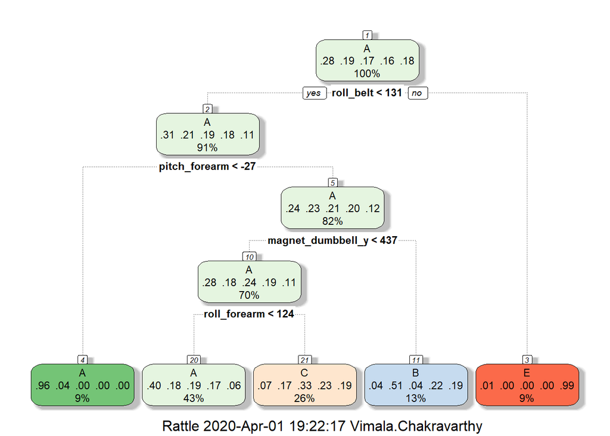

```r
fancyRpartPlot(modFit$finalModel)
```

#7.1 correlation test

```r
M <- abs(cor(training[,-53]))
diag(M) <- 0
which(M>0.8, arr.ind=T)
```

```
##                  row col
## yaw_belt           3   1
## total_accel_belt   4   1
## accel_belt_y       9   1
## accel_belt_z      10   1
## accel_belt_x       8   2
## magnet_belt_x     11   2
## roll_belt          1   3
## roll_belt          1   4
## accel_belt_y       9   4
## accel_belt_z      10   4
## pitch_belt         2   8
## magnet_belt_x     11   8
## roll_belt          1   9
## total_accel_belt   4   9
## accel_belt_z      10   9
## roll_belt          1  10
## total_accel_belt   4  10
## accel_belt_y       9  10
## pitch_belt         2  11
## accel_belt_x       8  11
## gyros_arm_y       19  18
## gyros_arm_x       18  19
## magnet_arm_x      24  21
## accel_arm_x       21  24
## magnet_arm_z      26  25
## magnet_arm_y      25  26
## accel_dumbbell_x  34  28
## accel_dumbbell_z  36  29
## gyros_dumbbell_z  33  31
## gyros_forearm_z   46  31
## gyros_dumbbell_x  31  33
## gyros_forearm_z   46  33
## pitch_dumbbell    28  34
## yaw_dumbbell      29  36
## gyros_forearm_z   46  45
## gyros_dumbbell_x  31  46
## gyros_dumbbell_z  33  46
## gyros_forearm_y   45  46
```

#7.2 Preprocess test

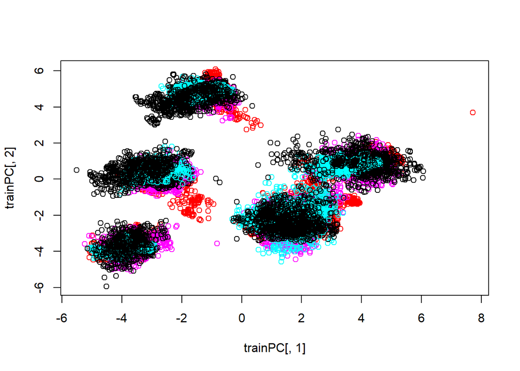

```r
library(caret)
preProc <- preProcess((training[,-53]+1), method="pca",pcaComp=2)
trainPC <- predict(preProc, (training[,-53]+1))

typeColor <- ((training$classe=="A")*1+ (training$classe=="B")*2 + (training$classe=="B")* 3 +(training$classe=="D")* 4 +1)
plot(trainPC[,1], trainPC[,2], col=typeColor)
```